# Implementation, Monitoring, and Learning

Week 4 Wednesday — Decision Systems in Practice

NRES 315: Human Dimensions of Fish and Wildlife Management

2026-09-18

## What happens after a plan is adopted?

Monday asked how a management problem is framed and how evidence can shape a plan.

**Today:** We follow the decision into the real work: choosing among alternatives, carrying an action out, finding out what happened, and changing course when necessary.

Source: Chapter 6, §§6.3–6.3.4

## By the end of class, you can

- explain what structured decision making makes visible in a contested management choice;
- distinguish implementation, monitoring, and evaluation in real management examples; and
- use both quantitative and qualitative evidence to diagnose what should change next.

Source: Chapter 6, §§6.3.1–6.3.4.2

## Plan–Do–Learn is a family of decision tools

Plan–Do–Learn is the shared iterative principle behind several tools, not the only way to manage.

Source: Chapter 6, §6.3 and Table 6.1

## Different tools fit different management problems

- **Structured decision making:** clarifies objectives, alternatives, consequences, tradeoffs, and monitoring needs.
- **Adaptive management:** uses monitoring to reduce uncertainty and update recurring decisions.
- **Systematic conservation planning:** selects spatial areas and features suited to conservation goals.
- **Manager’s model:** describes the social-ecological management system, problems, and desired conditions.
- **Open Standards:** applies a systematic, iterative conservation process.

Source: Chapter 6, Table 6.1.

Source: Chapter 6, Table 6.1

## Structured decision making makes tradeoffs discussable

It does not remove conflict, uncertainty, or value differences.

It makes them visible by documenting:

- objectives and alternatives;
- evidence and assumptions;
- consequences and tradeoffs; and
- public input and how the decision will be evaluated.

🌟 Transparency is not agreement. It is being able to show what was considered, what mattered, and how the decision can be revisited.

Source: Chapter 6, §6.3.1

## Deer tags: the biological answer is not the whole decision

When population estimates decline, a state agency might consider:

- reducing tags statewide;
- changing tags only in selected management units;
- changing season timing;
- improving habitat; or
- pairing harvest prescriptions with hunter-access programs.

Each alternative can be compared using biological outcomes, hunter satisfaction, perceived fairness, enforcement feasibility, and local economic effects.

Source: Chapter 6, §6.3.1.

Source: Chapter 6, §6.3.1

## Do: implementation is a stream of decisions

Implementation turns plans into action but it is not one single action.

Source: Chapter 6, §6.3.3

## Where implementation actually happens

Implementation happens in multiple places:

- formal rules and regulations;
- administrative policies and program delivery;
- meetings with publics, habitat restoration, enforcement, and surveys; and
- routine field-level choices made within plans, policies, and legal mandates.

🌟 “Doing” tests whether a plan is practical and relevant in its social, political, legal, and ecological context.

Source: Chapter 6, §6.3.3

## Emergency action still needs accountability

During highly pathogenic avian influenza outbreaks, an agency may have to:

- restrict wetland access;
- suspend hunting seasons; or
- impose carcass-transport rules quickly and with limited input.

Participation is not always possible in an emergency. Agencies still need to explain the action, assess what happened, and learn from the response.

Source: Chapter 6, §6.3.3.

Source: Chapter 6, §6.3.3

## Waterfowl zones show why implementation is social

Setting waterfowl hunting zones can require managers to balance:

- migration timing and population health;
- when and where hunters prefer to hunt;
- flyway guidance, harvest data, and migration models; and
- input from surveys, advisory panels, or public comments.

The final rule is one event. The implementation process is much larger.

Source: Chapter 6, §6.3.3.

Source: Chapter 6, §6.3.3

## Learn: monitoring records change; evaluation explains it

Monitoring records change. Evaluation explains what that change means for the next decision.

Source: Chapter 6, §6.3.4

## Monitor an objective, not just what is easy to count

A mule-deer plan set an objective to increase hunter satisfaction by 10% over five years. Managers could adjust seasons and harvest rules, then use annual or biennial post-season surveys to track encounters, satisfaction, and harvest rates before and after implementation.

🌟 The objective supplies the reason to monitor; the repeated design makes change interpretable.

Source: Chapter 6, §6.3.4.1.

Source: Chapter 6, §6.3.4.1

## Long-term social monitoring can reveal a changing public

The National Survey of Fishing, Hunting, and Wildlife-Associated Recreation has tracked participation, demographics, expenditures, and motivations roughly every five years since 1955.

Those data reveal changes in participation, access, and recreation—including growth in non-consumptive activities—and can prompt agencies to reconsider recruitment, retention, and funding strategies.

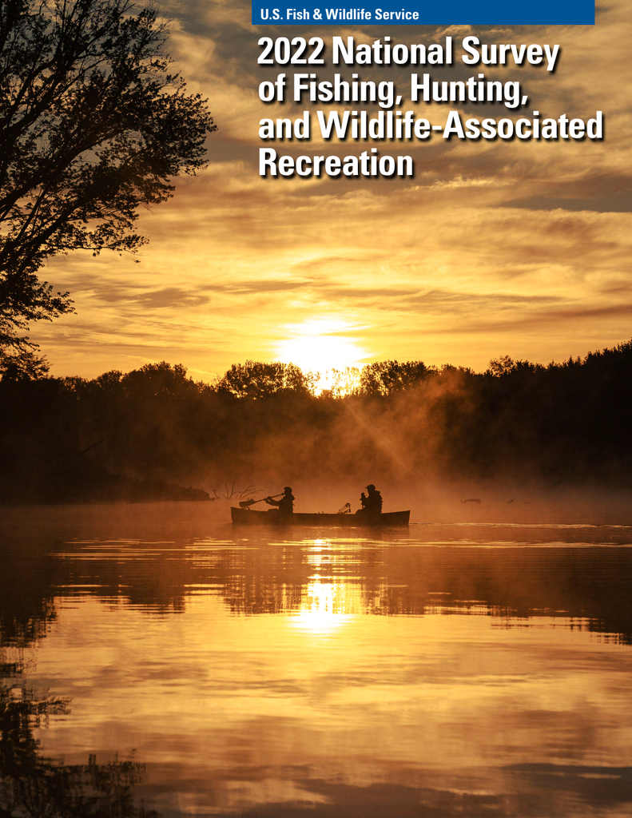

Source: Chapter 6, §6.3.4.1; U.S. Fish and Wildlife Service, *2022 National Survey of Fishing, Hunting, and Wildlife-Associated Recreation* (public domain).

Source: Chapter 6, §6.3.4.1

## Evaluation asks a harder question

> Did we accomplish what we set out to do?

Numbers such as license sales, harvest, population estimates, participation rates, and survey scores are useful benchmarks.

But numbers alone may not explain **why** an outcome occurred, whose experience is missing, or whether the monitoring system itself has a blind spot.

Source: Chapter 6, §6.3.4.2

## Qualitative evidence can test the monitoring system

Two examples show how qualitative evidence can matter:

- Interviews in Arizona surfaced values and concerns that culturally narrow survey questions missed—questions about whether people see wildlife mainly as a resource for human use or as part of a broader moral community.
- Interviews with fishing captains uncovered gaps between observed bycatch and what monitoring programs officially recorded, as well as reduction practices absent from agency data.

🌟 Qualitative evidence can explain a numerical pattern—or show that the pattern is incomplete.

Source: Chapter 6, §6.3.4.2.

Source: Chapter 6, §6.3.4.2

## Puget Sound: monitoring human well-being takes infrastructure

The Human Well-being Vital Signs were developed through a multi-year collaborative social-science process tied to regional recovery goals.

The system combines existing agency data with a state-funded biennial survey of 9,000 residents across 12 counties. Questions were pilot-tested and reviewed by a Social Science Advisory Committee.

[figure not shown]

Source: Chapter 6, Box 6.2; Puget Sound Partnership, *Puget Sound Vital Signs*.

Source: Chapter 6, Box 6.2

## The point of the Puget Sound indicators

They have helped the Partnership:

- evaluate residents’ experiences, behaviors, and perceived quality of life alongside ecological conditions;
- generate additional human-dimensions research;
- create an internal social-science position; and
- incorporate human-well-being priorities into recovery planning.

This is what it looks like when monitoring changes an institution’s capacity to make decisions.

Source: Chapter 6, Box 6.2.

Source: Chapter 6, Box 6.2

## Apply it: the barbed-hook decision

Try the process on one final decision problem.

Source: Chapter 6, §6.5, Review Question 3

## Case: restart a decision process

A state wildlife agency banned barbed hooks on a popular river fishery.

An angler survey later found that local publics were upset, felt they could no longer catch fish, and believed they had not been properly consulted.

In groups of three, prepare a two-minute response:

1. What did the original process fail to learn **before** implementation?
2. What biological and social evidence would you gather if you restarted it?
3. What would you monitor and evaluate after a revised decision?

Source: Chapter 6, §6.5, Review Question 3

## Friday: use Puget Sound as a decision system

For Friday, your group will use the Puget Sound evidence system to:

1. frame one specific recovery or restoration decision;
2. connect a Human Well-being Vital Sign, measure, and affected perspective;
3. recommend an implementation or coordination action and a tradeoff; and
4. state a possible monitoring result and how you would revise the plan.

**Submit:** role record + four sections (200–350 words) before class ends. Each present member then completes the private Group Check.

Source: Chapter 6, Box 6.2

## Close: learning changes the next decision

A defensible management process does not merely collect more information.

It makes objectives, alternatives, tradeoffs, implementation conditions, and outcomes visible enough that an agency can explain **what it will do differently next time**.

Source: Chapter 6, §§6.3.1–6.3.4.2